# Synthèse du stage de métabarcoding

Rémi Legrand

20/01/2022

```r
library(tidyverse) # permet de charger ggplot2, tibble, tidyr, readr, purrr, dyplyr
library(ROBITools2) #analyse des données métabarcoding
library(stringr) #pour manipuler les chaînes de caractères
library(openxlsx) #pour manipuler les fichiers .xlsx
library(igraph)
```

```r
motus <- read.table("motus_afrique_sud_remi2.txt")
data <- read.table("data_afrique_sud_remi2.txt")
samples <- read.table("samples_afrique_sud_remi2.txt")
reference <- read.xlsx("Plant reference collection sequence information.xlsx",
                       sheet = 2)
```

# 1 Introduction

L’objectif est d’estimer la biodiversité à partir de donnée de Métabarcoding( “technique de catalogage et d’identification moléculaire permettant la caractérisation génétique d’un individu ou d’un échantillon d’individu à partir d’une courte séquence d’ADN choisie en fonction du groupe étudié” : *Wikipedia*).  
Le problème de cette technique est qu’il y aura des erreurs lors de la PCR. Ce qui sera problématique lors de l’étude de la biodiversité vu que si on traite pas les données, touts les mutants seront considérés comme des espèces.

# 2 Rédaction des différentes fonction

## 2.1 Calcul d’une matrice de distance entre les séquences d’un jeu de données

Mise en place d’un filtre optionnel sur le nombre de lectures, permettant d’avoir un temps de calcul moins long.  
Utilisation du package ROBITools2 pour calculer les distances entre chacune des séquences (ici, on ne prend pas en compte quelle est la mutation).

```r
matrice_distance <- function(base_donnee, seuil) {
  base_donnee_bis <- base_donnee[base_donnee$count > seuil,] # création d'une nouvelle base de donné qui ne contient que des motus dont le nombre de reads est supérieur au seuil.

  x <- sapply(base_donnee_bis$sequence[1:nrow(base_donnee_bis)], lcs_score, base_donnee_bis$sequence[1:nrow(base_donnee_bis)], similarity_mode = "distance")

  matrice_dist <- matrix(unlist(x), nrow = length(base_donnee_bis$sequence[1:nrow(base_donnee_bis)]), ncol = length(base_donnee_bis$sequence[1:nrow(base_donnee_bis)]), byrow = T)

  return(matrice_dist)
}
```

## 2.2 Rajouter une colonne “dans ref” dans une base de donnée indiquant pour chacunes des sequences si elle est présente dans une base de reférence

```r
dans_ref <- function(base_donnee, ref){
  base_donnee[,"dans_ref"] <- F
  nrow(base_donnee)
  for (c in 1:nrow(base_donnee)) {
    if (base_donnee$sequence[c] %in% ref$Sequence.ID) {
      base_donnee$dans_ref[c] <- T

    }
  }
  return(base_donnee)
}
```

## 2.3 Calcul d’une matrice d’adjacence à partir d’une matrice de distance

Ici, nous voulons réaliser une matrice d’adjacence, qui est construite selon trois cas pris en compte:  
- Si l’espèce i appartient à la base de donnée alors elle ne descend de personne  
- Sinon, si au moins une espèce se trouve à 1 de distance génétique de i et a plus de lectures que i, alors i descend d’elle(s) et  
- Sinon, nous définissons ce motu comme une nouvelle espèce, elle ne descend alors de personne .

```r
matrice_adjacence <- function(matrice_distance, base_donnee_ref){
  couleur <- NULL
  matrice_adj <- matrix(data = NA, nrow = nrow(matrice_distance), ncol = ncol(matrice_distance))
  for (i in 1:nrow(matrice_distance)) {
    if (base_donnee_ref$dans_ref[i] == T) {
      matrice_adj[i,] <- 0 # n'est lié à rien d'autre
      couleur <- rbind(couleur, "green")
    }else {
      if (1 %in% matrice_distance[i,1:(i-1)]) { # si il y a au moins un motu à 1 de distance génétique
        a <- which(matrice_distance[i,1:(i-1)] == 1) # on marque lesquels sont à un de distance
        if (length(a) == 1) {
          matrice_adj[i,] <- 0
          matrice_adj[i,a] <- 1 # se rattache à cette espèce
          couleur <- rbind(couleur, "yellow")
        }else {
          matrice_adj[i,] <- 0
          matrice_adj[i,a] <- 1 # lié aux deux mais perte de l'info de la répartition entre les deux
          couleur <- rbind(couleur, "yellow")
        }
      }else{
        matrice_adj[i,] <- 0 # définition d'une probable nouvelle espèce
        couleur <- rbind(couleur, "red")
      }
    }
  }
  return(matrice_adj)
}
```

## 2.4 Calcul d’une matrice de Probabilité

Ici, nous voulons réaliser une matrice d’adjacence, qui est construite selon trois cas pris en compte:  
- Si l’espèce i appartient à la base de donnée -> probabilité que i appartienne à lui même est de 1, qu’il appartienne à n’importe quelle autre espèce.  
- Sinon, si au moins une espèce se trouve à 1 de distance génétique de i et a plus de lectures que i, alors elle répartis les lectures de i proportionnelement à celui des autres espèces.  
- Sinon, nous définissons ce motu comme une nouvelle espèce.

```r
matrice_probabilite <- function(matrice_distance, base_donnee_ref){
  matrice_proba <- matrix(data = NA, nrow = nrow(matrice_distance), ncol = ncol(matrice_distance))
  for (i in 1:nrow(matrice_distance)) {
    if (base_donnee_ref$dans_ref[i] == T) {
      matrice_proba[i,] <- 0
      matrice_proba[i,i] <- 1
    }else {
      if (1 %in% matrice_distance[i,1:(i-1)]) {
        a <- which(matrice_distance[i,1:(i-1)] == 1)
        if (length(a) == 1) {
          matrice_proba[i,] <- 0
          matrice_proba[i,a] <- 1
        }else {
          matrice_proba[i,] <- 0
          matrice_proba[i,a] <- (base_donnee_ref$count[a]/sum(base_donnee_ref$count[a]))
        }
      }else{
        matrice_proba[i,] <- 0
        matrice_proba[i,i] <- 1
      }
    }
  }
  return(matrice_proba)
}
```

## 2.5 Édition d’une liste permettant de colorer le graphe

en vert nous mettons les espèces appartenant à la référence  
en rouge les nouvelles espèces supposées  
en jaune les variant supposés

```r
liste_couleur <- function(matrice_distance, base_donnee_ref){
  couleur <- NULL
  matrice_adj <- matrix(data = NA, nrow = nrow(matrice_distance), ncol = ncol(matrice_distance))
  for (i in 1:nrow(matrice_distance)) {
    if (base_donnee_ref$dans_ref[i] == T) {
      couleur <- rbind(couleur, "green")
    }else {
      if (1 %in% matrice_distance[i,1:(i-1)]) { # si il y a au moins un motu à 1 de distance génétique
          couleur <- rbind(couleur, "yellow")
      }else{
        couleur <- rbind(couleur, "red")
      }
    }
  }
  return(couleur)
}
```

## 2.6 Tracé du graphe

```r
graphe <- function(matrice_adjacence,base_donnee, couleur) {
  graph_liens <- graph_from_adjacency_matrix(matrice_adjacence[1:nrow(matrice_adjacence),1:nrow(matrice_adjacence)])
  V(graph_liens)$color <- couleur
  V(graph_liens)$size <- 3*log10(base_donnee$count)

  return(tkplot(graph_liens, mode='directed'))
}
```

## 2.7 Calcul du spectre de Hill

```r
spectre_hill <- function(val,q){
  val <- val[val !=0]
  ps <- val/sum(val)
  if (q == 1) {
    a <- exp(-sum(ps*log(ps)))
  }else if (q == 0){
    a <-length(val)
  }else {
    a <- sum(ps^q)^(1/(1-q))
  }
  return(a)
}
```

# 3 Tracé du graphe des distances de Motu

```r
distance <- matrice_distance(motus, 2000)
motus_ref <- dans_ref(motus,reference)
matrice_adj <- matrice_adjacence(distance, motus_ref)
couleur <- liste_couleur(distance, motus_ref)
graphe(matrice_adj, motus, couleur)
```

```
## [1] 1
```

# 4 Ajout d’un seuil

```r
seuil_arbitraire <- 4000
```

# 5 Tracé des spectre de hill selon les différents filtres appliqués aux données

## 5.1 Fusion partielle des fichiers de motu et data

Mettre les séquences d’adn de sample vers data

```r
data %>% left_join(select(motus,id,sequence) , by = c("motu" = "id")) %>%
  drop_na() -> data
head(data)
```

```
##       motu sample count                                             sequence
## 1 GH000001 P16S_3  1054 atcccttttttgaaaaaccaagtggttctcaaaccagaagccaaaggaaaag
## 2 GH000001 P16S_2  1343 atcccttttttgaaaaaccaagtggttctcaaaccagaagccaaaggaaaag
## 3 GH000001 P16S_1  1371 atcccttttttgaaaaaccaagtggttctcaaaccagaagccaaaggaaaag
## 4 GH000001 W20W_2  4452 atcccttttttgaaaaaccaagtggttctcaaaccagaagccaaaggaaaag
## 5 GH000001 R07A_1   945 atcccttttttgaaaaaccaagtggttctcaaaccagaagccaaaggaaaag
## 6 GH000001 R07A_3  1149 atcccttttttgaaaaaccaagtggttctcaaaccagaagccaaaggaaaag
```

Ajout d’une colonne séquence dans la base de données data en fusionnant la colonne séquence de motus motu et id

## 5.2 Matrice de distance

```r
mat_dist2 <- matrice_distance(motus,seuil_arbitraire)
rownames(mat_dist2) <- as.factor(motus$id[motus$count >seuil_arbitraire])
colnames(mat_dist2) <- as.factor(motus$id[motus$count >seuil_arbitraire])
```

## 5.3 Matrice de Proba

```r
motus_ref <- dans_ref(motus, reference)

mat_proba2 <- matrice_probabilite(mat_dist2, motus_ref)
rownames(mat_proba2) <- as.factor(motus$id[motus$count >seuil_arbitraire])
colnames(mat_proba2) <- as.factor(motus$id[motus$count >seuil_arbitraire])
```

Création d’une image de motus avec une colonne dans ref supplémentaire puis création d’une matrice de proba

## 5.4 Attribution des probabilitées d’appartenance des mutant à la sequence dont ils sont dérivés.

```r
for (a in 1:nrow(mat_proba2)) {
  enfants <- which(mat_proba2[,a] != 0)
  if (mat_proba2[a,a] != 1 & length(enfants) != 0) {
    parents <- which(mat_proba2[a,] != 0)
    mat_proba2[enfants, parents] <- mat_proba2[enfants,parents] + matrix(mat_proba2[enfants,a], nrow = length(enfants)) %*% matrix(mat_proba2[a,parents],nrow = 1)
    mat_proba2[enfants,a] <- 0

  }
}
```

Si une séquence a n’est pas attribuée à elle même (a un parent autre que lui) et qu’elle a des enfants (mutants lui étant dérivés), alors on ajoute la proba des enfants à celle des parents de a. Ainsi, les probabilités d’appartenance des séquences mutées sont donc maintenant redirigées vers le motu d’origine.

```r
parentee <- function(indiv) {
  setequal(indiv ,which(mat_proba2[indiv,] != 0))
}

faux = 0
for (a in 1:nrow(mat_proba2)) {
  parent_a <- which(mat_proba2[a,] != 0)
  if ( length(which(!sapply(parent_a,parentee))) != 0 ) {
    faux <- faux + 1
    print(a)
  }
}
faux
```

```
## [1] 0
```

```r
nrow(mat_proba2)
```

```
## [1] 653
```

Vérification que toutes les probabilités des séquences mutées ont bien été attribuées au motu d’origine (ici, que le parent de a est bien le même que le parent du parent de a).

## 5.5 Vecteur contenant les counts

```r
motus[,c("id","count")] %>% filter(count >seuil_arbitraire) %>% left_join(select(motus_ref, id), by = c("id" = "id")) -> vect_count
```

Création d’un vecteur contenant les counts correspondant aux motus sélectionné dans la matrice de probabilité précédente.

## 5.6 Produit matriciel afin d’obtenir les counts théoriques

```r
count_th <- t(t(vect_count$count) %*% mat_proba2) # produit matriciel entre la matrice de proba et le vecteur contenant les counts de la base de données utilisé

colnames(count_th) = "count"
```

Produit matriciel entre la vecteur de count et la matrice de proba afin d’obtenir un vecteur contenant le nombre de count théorique des motus d’origine.

## 5.7 Comparaison des spectres de Hill selon le filtre appliqué

```r
q_values = seq(0,3,0.1)

comparaison_spectre_hill = data_frame()
```

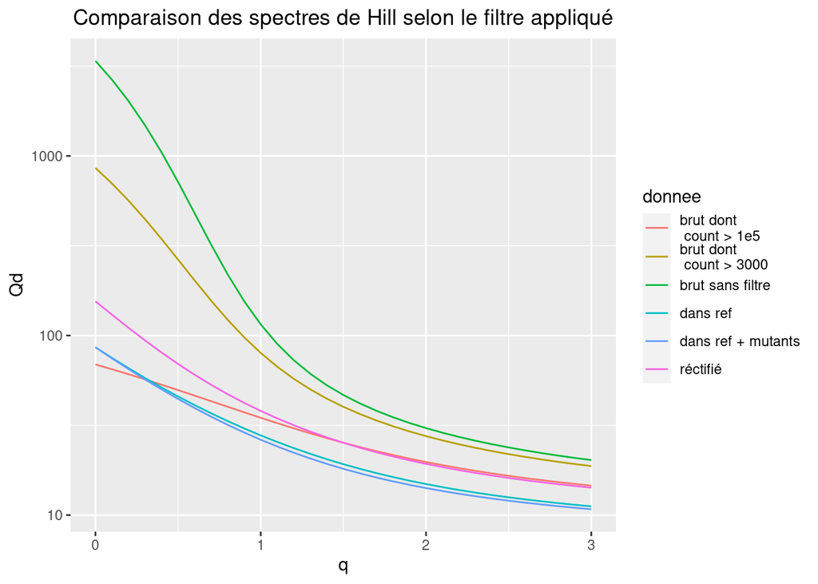

```r
d = data.frame(donnee = "réctifié", q = q_values)
comparaison_spectre_hill <- rbind(comparaison_spectre_hill, d %>% group_by(q) %>% mutate(Qd =  spectre_hill(val = count_th, q = q)))

d = data.frame(donnee = "brut sans filtre", q = q_values)
comparaison_spectre_hill <- rbind(comparaison_spectre_hill, d %>% group_by(q) %>% mutate(Qd =  spectre_hill(val = motus$count, q = q)))

d = data.frame(donnee = "brut dont \n count > 3000", q = q_values)
comparaison_spectre_hill <- rbind(comparaison_spectre_hill, d %>% group_by(q) %>% mutate(Qd =  spectre_hill(val = motus$count[ motus$count>3000], q = q)))

d = data.frame(donnee = "brut dont \n count > 1e5", q = q_values)
comparaison_spectre_hill <- rbind(comparaison_spectre_hill, d %>% group_by(q) %>% mutate(Qd =  spectre_hill(val = motus$count[ motus$count>1e5], q = q)))

d = data.frame(donnee = "dans ref", q = q_values)
comparaison_spectre_hill <- rbind(comparaison_spectre_hill, d %>% group_by(q) %>% mutate(Qd =  spectre_hill(val = motus_ref[motus_ref$dans_ref & motus_ref$count>seuil_arbitraire,]$count, q = q)))

count_th_df <- as.data.frame(count_th)
count_th_df$motu <-row.names(count_th_df)
count_th_df %>% left_join(select(motus_ref,id,dans_ref) , by = c( "motu" = "id")) -> count_th_ref
# count_th_ref # rajouter une colonne indiquant si le motu est dans la ref

d = data.frame(donnee = "dans ref + mutants", q = q_values)
comparaison_spectre_hill <- rbind(comparaison_spectre_hill, d %>% group_by(q) %>% mutate(Qd =  spectre_hill(val = count_th_ref[count_th_ref$dans_ref,]$count, q = q)))

ggplot(data = comparaison_spectre_hill, aes(x = q, y = Qd, group = donnee, colour = donnee)) +
  geom_line() +
  scale_y_log10() +
  ggtitle("Comparaison des spectres de Hill selon le filtre appliqué") +
  theme(plot.title = element_text(hjust = 0.5))
```

# 6 Comparaison des spectre de hills par espèce

## 6.1 Fusion partielle de data avec samples afin d’obtenir pour chaque échantillon le nom de l’espèce dont il est issu

```r
data %>% left_join(select(samples,id,observed_scientific_name) , by = c("sample" = "id")) %>%
  drop_na() %>% rename(espece = observed_scientific_name) -> data
```

pour lier les nom des espèces aux échantillons qui leurs appartiennent

## 6.2 Mise en forme des données

```r
data %>% group_by(espece,motu) %>% summarise(count = sum(count)) -> data_short # regroupement des count d'un même motu pour chaque espèce
data_short %>% left_join(select(motus_ref,id,dans_ref) , by = c("motu" = "id")) -> data_short_ref # annotation afin de savoir pour chaque ligne si le motu associé appartient à la base de données
which(is.na(data_short_ref$dans_ref)) #vérification que toutes les lignes ont bien un booléen associé dans la colonne dans_ref
```

```
## integer(0)
```

## 6.3 Comparaison des spectre de Hill selon les espèces

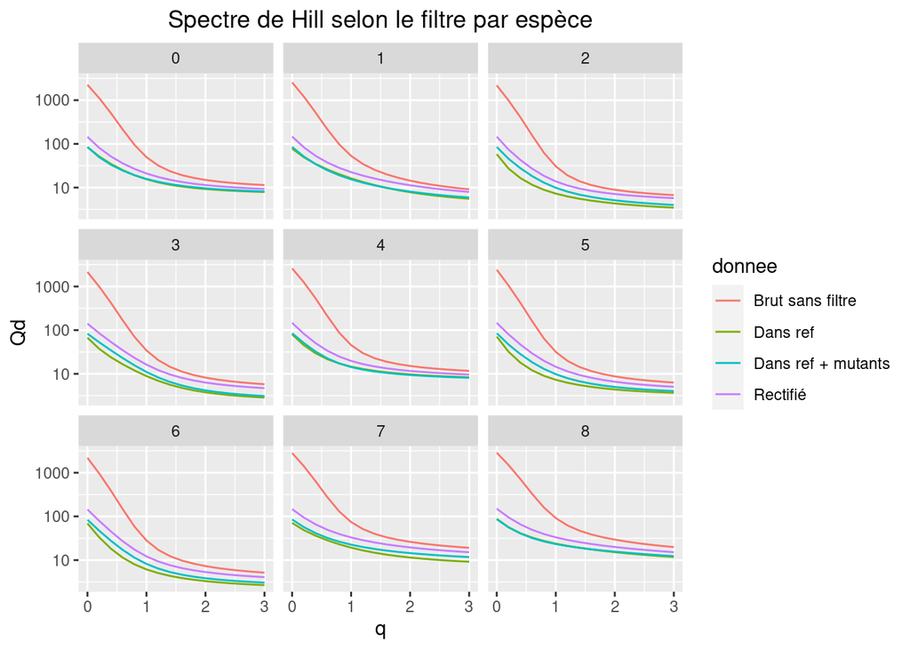

```r
# data %>% drop_na() -> data
especes = unique(data$espece)
especes = especes[!is.na(especes)]
q_values = seq(0,3,0.2)



df_spectre_hill = data.frame()
for (e in especes[1:9]) {
  d = data.frame(espece = e, donnee = "Brut sans filtre" ,q = q_values)
  val = data_short[data_short$espece == e,]$count
  df_spectre_hill <- rbind(df_spectre_hill, d %>% group_by(q) %>% mutate(Qd =  spectre_hill(val = val, q = q)))

  d = data.frame(espece = e, donnee = "Rectifié" ,q = q_values)
  data_short[data_short$espece == e, c("motu","count")] %>% right_join(select(motus_ref[motus_ref$count > seuil_arbitraire,], id), by = c("motu" = "id")) -> sub_vect_count # rédaction d'un vecteur avec les counts et de la dimension de la matrice de proba
  sub_vect_count[is.na(sub_vect_count$count),]$count <- 0 # remplacement des NA par des 0
  sub_count_th <- t(t(sub_vect_count$count) %*% mat_proba2)# produit matriciel entre count et mat proba
  colnames(sub_count_th) = "count"
  val = sub_count_th
  df_spectre_hill <- rbind(df_spectre_hill, d %>% group_by(q) %>% mutate(Qd =  spectre_hill(val = val, q = q))) # spectre de hill pour tout les échantillons apparentant à une même espèce

  d = data.frame(espece = e, donnee = "Dans ref" ,q = q_values)
  val = data_short_ref[data_short_ref$dans_ref == T & data_short_ref$espece ==e,]$count
  df_spectre_hill <- rbind(df_spectre_hill, d %>% group_by(q) %>% mutate(Qd =  spectre_hill(val = val, q = q)))

  sub_count_th_df <- as.data.frame(sub_count_th)
  sub_count_th_df$motu <-row.names(sub_count_th_df)
  sub_count_th_df %>% left_join(select(motus_ref,id,dans_ref) , by = c( "motu" = "id")) -> sub_count_th_ref
  d = data.frame(espece = e, donnee = "Dans ref + mutants" ,q = q_values)
  val = sub_count_th_ref[sub_count_th_ref$dans_ref,]$count
  df_spectre_hill <- rbind(df_spectre_hill, d %>% group_by(q) %>% mutate(Qd =  spectre_hill(val = val, q = q)))

}

# View(df_spectre_hill)
Graph <- ggplot(data = df_spectre_hill, aes(x = q, y = Qd, colour = donnee)) +
  geom_line() +
  scale_y_log10() +
  ggtitle("Spectre de Hill selon le filtre par espèce") +
  theme(plot.title = element_text(hjust = 0.5))

Graph + facet_wrap(facets = ~ (as.numeric(as.factor(espece))%%9))
```

# 7 Tracer les spectre de Hill bruts avec des filtre de différentes puissance sur les Counts

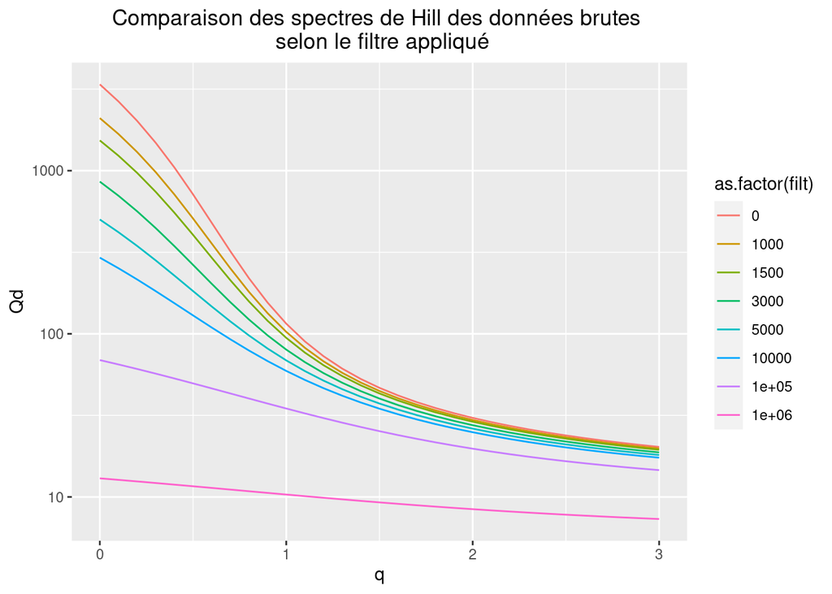

```r
q_values = seq(0,3,0.1)
filtre <- c(0,1000,1500,3000,5000,1e4,1e5,1e6)
comparaison_filtres_spectre_hill = data_frame()
for (f in filtre) {
  d = data.frame(filt = f, q = q_values)
  comparaison_filtres_spectre_hill <- rbind(comparaison_filtres_spectre_hill, d %>% group_by(q) %>% mutate(Qd =  spectre_hill(val = motus$count[ motus$count>f], q = q)))
}



ggplot(data = comparaison_filtres_spectre_hill, aes(x = q, y = Qd, group = filt, colour = as.factor(filt))) +
  geom_line() +
  scale_y_log10() +
  ggtitle("Comparaison des spectres de Hill des données brutes \n selon le filtre appliqué") +
  theme(plot.title = element_text(hjust = 0.5))
```

```r
# summary(motus)
```

# 8 Comparaison de la diversité du regime alimentaire de espèces

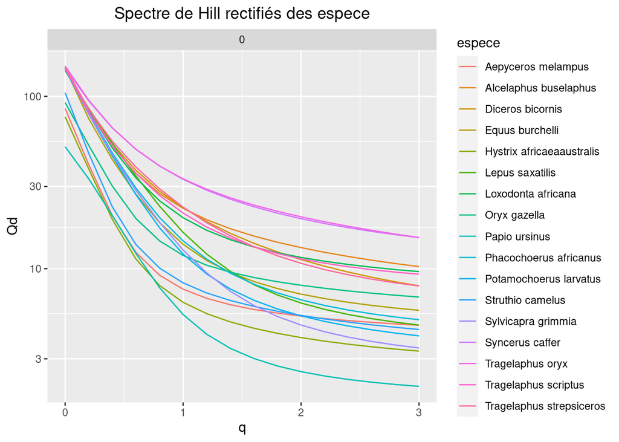

```r
especes = unique(data$espece)
especes = especes[!is.na(especes)]
q_values = seq(0,3,0.2)



df_spectre_hill = data.frame()
for (e in especes) {
  d = data.frame(espece = e, q = q_values)
  data_short[data_short$espece == e, c("motu","count")] %>% right_join(select(motus_ref[motus_ref$count > seuil_arbitraire,], id), by = c("motu" = "id")) -> sub_vect_count # rédaction d'un vecteur avec les counts et de la dimension de la matrice de proba
  sub_vect_count[is.na(sub_vect_count$count),]$count <- 0 # remplacement des NA par des 0
  sub_count_th <- t(t(sub_vect_count$count) %*% mat_proba2)# produit matriciel entre count et mat proba
  colnames(sub_count_th) = "count"
  val = sub_count_th
  df_spectre_hill <- rbind(df_spectre_hill, d %>% group_by(q) %>% mutate(Qd =  spectre_hill(val = val, q = q))) # spectre de hill pour tout les échantillons apparentant à une même espèce
}

# View(df_spectre_hill)
Graph <- ggplot(data = df_spectre_hill, aes(x = q, y = Qd, group_by= espece ,colour = espece)) +
  geom_line() +
  scale_y_log10() +
  ggtitle("Spectre de Hill rectifiés des espece") +
  theme(plot.title = element_text(hjust = 0.5))

Graph + facet_wrap(facets = ~ (as.numeric(as.factor(espece))%%1))
```

# 9 ACP

## 9.1 Construction d’un dataframe conenant le nombre de read rectifié par espèces

```r
df_espece = data.frame()
for (e in especes) {
  data_short[data_short$espece == e, c("motu","count")] %>% right_join(select(motus_ref[motus_ref$count > seuil_arbitraire,], id), by = c("motu" = "id")) -> sub_vect_count # rédaction d'un vecteur avec les counts et de la dimension de la matrice de proba
  sub_vect_count[is.na(sub_vect_count$count),]$count <- 0 # remplacement des NA par des 0

  sub_count_th <- t(t(sub_vect_count$count) %*% mat_proba2)# produit matriciel entre count et mat proba
  mini_df_espece <- t(as.numeric(sub_count_th))
  df_espece <- rbind(df_espece, mini_df_espece)
  df_espece
}

colnames(df_espece) = motus_ref[motus_ref$count > seuil_arbitraire,]$id
rownames(df_espece) = especes

a_retirer <- c()
for (a in 1:ncol(df_espece)) {
  if (setequal(df_espece[,a],rep(0,17))) {
    a_retirer <- rbind(a_retirer,a)
  }
}
df_espece[,a_retirer] = NULL

for (a in 1:nrow(df_espece)) {
  df_espece[a,] <- df_espece[a,]/nrow(samples[samples$observed_scientific_name == rownames(df_espece)[a],])
}



df_espece
```

```
##                               GH000001     GH000002     GH000003     GH000007
## Phacochoerus africanus    3.017014e+03 2.029147e+03 1.089694e+02 4.666106e+02
## Diceros bicornis          3.467311e+02 5.407595e+01 1.400835e+02 1.868960e+01
## Tragelaphus oryx          1.576965e+02 1.472666e+02 5.801788e+02 9.206755e+01
## Loxodonta africana        7.593193e+02 4.761444e+02 1.156080e+02 6.966735e+01
## Lepus saxatilis           1.882725e+03 4.382119e+02 7.180835e+01 3.172025e+01
## Tragelaphus scriptus      5.618815e+01 5.634565e+01 3.485128e+02 9.899148e+00
## Equus burchelli           8.112364e+02 2.132408e+03 1.233589e+02 1.729801e+03
## Syncerus caffer           6.019564e+02 6.853068e+02 1.196910e+02 1.990962e+02
## Potamochoerus larvatus    1.750056e+03 4.962138e+01 1.240854e+02 1.926677e+01
## Alcelaphus buselaphus     3.587620e+02 1.728629e+03 1.140143e+02 7.904359e+02
## Tragelaphus strepsiceros  1.011638e+02 1.068105e+02 9.685337e+02 2.992048e+01
## Sylvicapra grimmia        1.780758e+02 1.857470e+02 3.517395e+03 3.680532e+01
## Oryx gazella              8.048780e-02 3.204878e+00 9.746341e+00 4.395122e+00
## Struthio camelus          8.336538e+00 3.739782e+01 7.836538e-01 1.009615e-01
## Hystrix africaeaaustralis 3.481327e+01 2.211302e-02 9.828010e-03 7.001720e+01
## Papio ursinus             1.474201e-02 1.228501e-02 2.186732e+00 7.371007e-03
## Aepyceros melampus        3.415233e-01 2.194103e+00 9.312039e-01 9.828010e-03
##                               GH000008     GH000009     GH000010     GH000011
## Phacochoerus africanus    2.808762e+01 4.396290e+01 3.141594e+02 1.341168e+01
## Diceros bicornis          4.394583e+01 2.119171e+02 8.100178e+00 9.222987e+02
## Tragelaphus oryx          1.840954e+02 8.822214e+01 1.552550e+02 6.356291e+00
## Loxodonta africana        1.257216e+01 5.757243e+01 2.276298e+01 7.509693e+02
## Lepus saxatilis           1.193663e+01 1.005622e+03 1.206692e+02 3.211437e+01
## Tragelaphus scriptus      4.529375e+02 2.855943e+01 1.131102e+01 2.439489e+01
## Equus burchelli           1.337962e+01 2.386493e+01 6.256480e+02 3.359084e+01
## Syncerus caffer           2.451487e+02 8.727442e+01 1.224510e+02 1.030612e+01
## Potamochoerus larvatus    2.258994e+01 5.333107e+02 1.941492e+01 1.633369e+02
## Alcelaphus buselaphus     4.878337e+02 3.699813e+01 7.093147e+02 1.384204e+01
## Tragelaphus strepsiceros  1.045061e+03 6.085763e+01 2.167382e+01 2.394940e+01
## Sylvicapra grimmia        1.102235e+03 1.990802e+02 7.606063e+01 1.574849e+01
## Oryx gazella              1.024390e-01 1.745732e+00 2.439024e-03 2.439024e-03
## Struthio camelus          3.471394e+01 9.056791e-01 1.788462e+00 1.995192e-01
## Hystrix africaeaaustralis 1.719902e-02 2.457002e-03 2.457002e-03 1.941032e-01
## Papio ursinus             4.914005e-03 9.828010e-03 4.422604e-02 3.120393e-01
## Aepyceros melampus        1.551843e+01 2.626014e-02 4.914005e-03 7.690418e-01
##                               GH000013     GH000014    GH000016     GH000017
## Phacochoerus africanus    1.818584e+01 2.881836e+02   3.0180807  39.95100902
## Diceros bicornis          1.325493e+01 1.380673e+01 218.2122987 171.51833748
## Tragelaphus oryx          2.027089e+02 7.903179e+01 108.0582781 224.00635081
```

[output cut: 629 more lines]

```
## Tragelaphus oryx          0.15231788 0.205298
## Loxodonta africana        0.00000000 0.000000
## Lepus saxatilis           0.00000000 0.000000
## Tragelaphus scriptus      0.00000000 0.000000
## Equus burchelli           0.00000000 0.000000
## Syncerus caffer           0.00000000 0.000000
## Potamochoerus larvatus    0.00000000 0.000000
## Alcelaphus buselaphus     0.02137767 0.000000
## Tragelaphus strepsiceros  0.00000000 0.000000
## Sylvicapra grimmia        0.00000000 0.000000
## Oryx gazella              0.00000000 0.000000
## Struthio camelus          0.00000000 0.000000
## Hystrix africaeaaustralis 0.00000000 0.000000
## Papio ursinus             0.00000000 0.000000
## Aepyceros melampus        0.00000000 0.000000
```

```r
rowSums(df_espece)
```

```
##    Phacochoerus africanus          Diceros bicornis          Tragelaphus oryx
##               9743.573018               3820.225476               4090.529801
##        Loxodonta africana           Lepus saxatilis      Tragelaphus scriptus
##               4793.100307               5566.406491               2722.346591
##           Equus burchelli           Syncerus caffer    Potamochoerus larvatus
##               8032.601182               5528.679300               4595.913110
##     Alcelaphus buselaphus  Tragelaphus strepsiceros        Sylvicapra grimmia
##               9317.103325               5126.595181               8141.752116
##              Oryx gazella          Struthio camelus Hystrix africaeaaustralis
##                 43.212195                395.509615                163.090909
##             Papio ursinus        Aepyceros melampus
##                  3.565111                 60.842752
```

```r
library(ade4)

a <- dudi.pca(df_espece, nf=ncol(df_espece), scannf = F)

inertia.dudi(a, col.inertia = T,row.inertia = T)$tot.inertia
```

```
##           inertia       cum    cum(%)
## Ax1  30.227782183  30.22778  20.15185
## Ax2  20.296023451  50.52381  33.68254
## Ax3  18.376930352  68.90074  45.93382
## Ax4  15.600717429  84.50145  56.33430
## Ax5  12.974933907  97.47639  64.98426
## Ax6  11.285855082 108.76224  72.50816
## Ax7  10.687596451 119.44984  79.63323
## Ax8   7.733210438 127.18305  84.78870
## Ax9   7.406652990 134.58970  89.72647
## Ax10  6.492230055 141.08193  94.05462
## Ax11  4.918029594 145.99996  97.33331
## Ax12  3.824066001 149.82403  99.88269
## Ax13  0.095615229 149.91964  99.94643
## Ax14  0.044882479 149.96453  99.97635
## Ax15  0.029203395 149.99373  99.99582
## Ax16  0.006270964 150.00000 100.00000
```

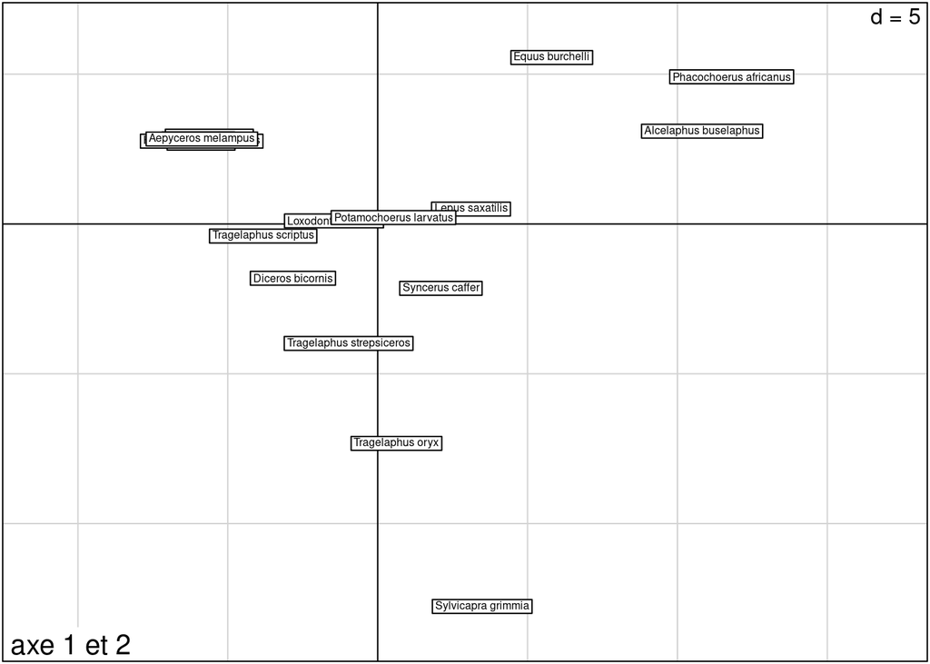

```r
s.label(a$li,xax = 1, yax = 2, sub = "axe 1 et 2",clabel = 0.5)
```

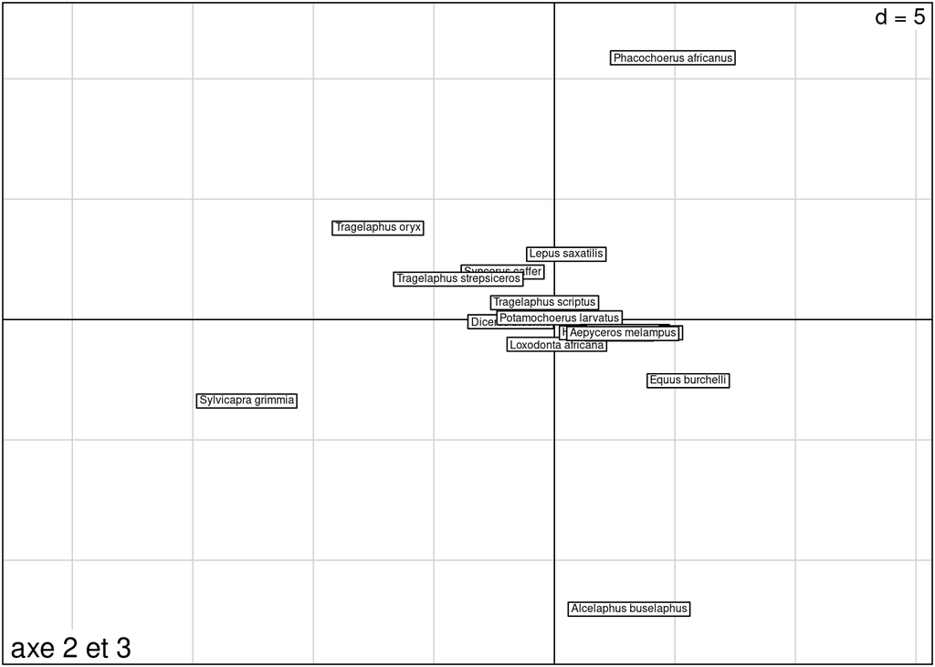

```r
s.label(a$li,xax = 2, yax = 3, sub = "axe 2 et 3",clabel = 0.5)
```

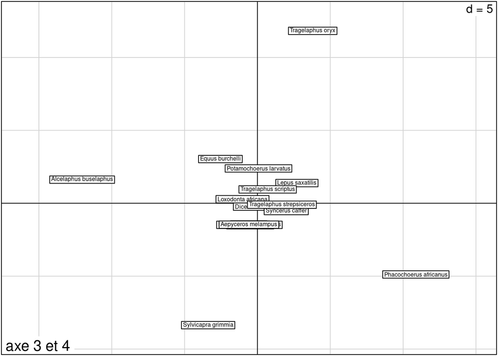

```r
s.label(a$li,xax = 3, yax = 4, sub = "axe 3 et 4",clabel = 0.5)
```

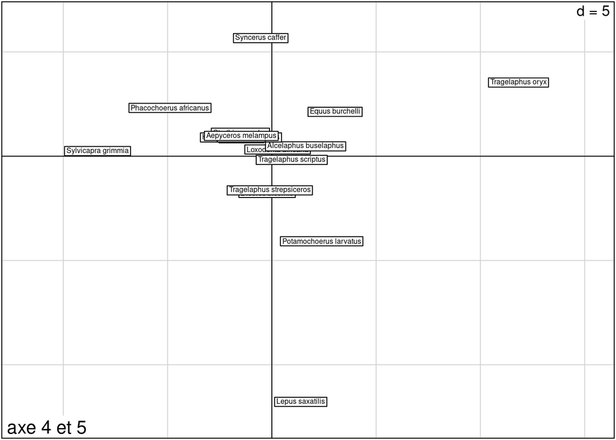

```r
s.label(a$li,xax = 4, yax = 5, sub = "axe 4 et 5",clabel = 0.5)
```

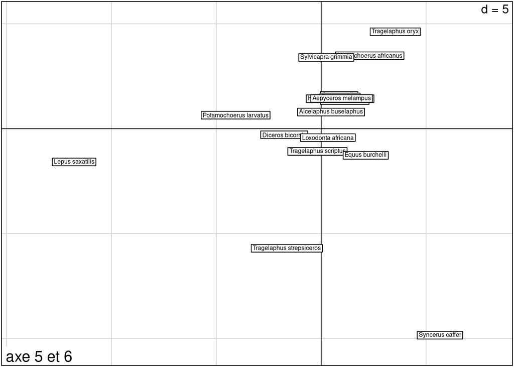

```r
s.label(a$li,xax = 5, yax = 6, sub = "axe 5 et 6",clabel = 0.5)
```

```r
a$li
```

```
##                                Axis1       Axis2        Axis3       Axis4
## Phacochoerus africanus    11.8089154   4.9115206  10.87312835 -4.88370945
## Diceros bicornis          -2.8276286  -1.8128780  -0.08978125 -0.22951747
## Tragelaphus oryx           0.6270274  -7.3239580   3.79397021 11.82562855
## Loxodonta africana        -1.4566498   0.1010671  -1.02686023  0.27628909
## Lepus saxatilis            3.1124150   0.4957436   2.70931538  1.38576755
## Tragelaphus scriptus      -3.8207353  -0.4042172   0.70058196  0.95131909
## Equus burchelli            5.8085269   5.5542299  -2.54233776  3.03277211
## Syncerus caffer            2.1083460  -2.1477768   1.97459374 -0.53299467
## Potamochoerus larvatus     0.5265471   0.2133274   0.07160157  2.38731273
## Alcelaphus buselaphus     10.8237569   3.0969759 -12.03144136  1.61926683
## Tragelaphus strepsiceros  -0.9701182  -3.9868618   1.67803013 -0.09812285
## Sylvicapra grimmia         3.4863503 -12.7653586  -3.38550024 -8.35874097
## Oryx gazella              -5.8925425   2.6957452  -0.59799543 -1.45512029
## Struthio camelus          -5.6159244   2.9318270  -0.49579416 -1.50626651
## Hystrix africaeaaustralis -5.8712184   2.7630662  -0.55061730 -1.48012924
## Papio ursinus             -5.9825918   2.8419440  -0.49792424 -1.46831615
## Aepyceros melampus        -5.8644760   2.8356035  -0.58296938 -1.46543835
##                                 Axis5      Axis6       Axis7       Axis8
## Phacochoerus africanus      2.3146918  3.4768704 -2.32002132 -0.20767264
## Diceros bicornis           -1.7612699 -0.2921784 -1.75950391  2.87534770
## Tragelaphus oryx            3.5322679  4.6191812 -0.75119691 -1.48664451
## Loxodonta africana          0.3220899 -0.4272662 -0.54509078  5.34163394
## Lepus saxatilis           -11.7795699 -1.5876145  0.46220611 -1.83690414
## Tragelaphus scriptus       -0.1771065 -1.0859374 -1.73594391 -0.11669466
## Equus burchelli             2.1258279 -1.2731916 10.97042192 -0.56069430
## Syncerus caffer             5.6617531 -9.8506314 -1.52354570  2.11208377
## Potamochoerus larvatus     -4.0780443  0.6434381  0.61287181  6.57159464
## Alcelaphus buselaphus       0.4717269  0.7905914 -5.82641652 -1.61397990
## Tragelaphus strepsiceros   -1.6376213 -5.7064631 -0.36374761 -5.70690179
## Sylvicapra grimmia          0.2464195  3.3934447  3.44840719  0.04713813
## Oryx gazella                0.8598841  1.5854133 -0.14331915 -1.12187080
## Struthio camelus            1.1256897  1.3368066 -0.21711085 -1.07249660
## Hystrix africaeaaustralis   0.9006842  1.4273203 -0.04908047 -1.12778969
## Papio ursinus               0.9006349  1.5101657 -0.11066381 -1.11186751
## Aepyceros melampus          0.9719422  1.4400510 -0.14826609 -0.98428163
##                                Axis9     Axis10       Axis11      Axis12
## Phacochoerus africanus    -0.8498561  0.8976122 -0.249698432 -0.15929815
## Diceros bicornis          -8.0964590 -1.1806190  4.385044019 -1.94263148
## Tragelaphus oryx           0.5470075 -1.1438895  0.416423297  0.70057540
```

[output cut: 35 more lines]

```
## Tragelaphus oryx          -2.192532e-04
## Loxodonta africana         7.674360e-04
## Lepus saxatilis            1.196347e-04
## Tragelaphus scriptus       4.712195e-04
## Equus burchelli            7.259688e-04
## Syncerus caffer            1.120851e-03
## Potamochoerus larvatus    -7.340266e-04
## Alcelaphus buselaphus      9.418592e-04
## Tragelaphus strepsiceros  -6.117217e-05
## Sylvicapra grimmia         1.020012e-03
## Oryx gazella              -4.956494e-02
## Struthio camelus          -2.070048e-02
## Hystrix africaeaaustralis -1.614973e-01
## Papio ursinus              2.747110e-01
## Aepyceros melampus        -4.656615e-02
```

Oryx gazella Struthio camelus Hystrix africaeaaustralis Papio ursinus Aepyceros melampus

Ces espèces semblent avoir un régime alimentaire similaire si on ne regarde que l’ACP. Cependant, si on regarde plus en détail , on s’appercoit qu’il y a un nombre de lectures moyen par échantillon très faible, ce qui fait que l’ACP les a regroupé ensemble.